# NFL Scraper

RWW

April 24, 2019

## Scraping NFL data

The `nflscrapR` package is designed to make data on NFL games more easily available. To install the package, we need to grab it from github.

```r
devtools::install_github(repo = "maksimhorowitz/nflscrapR")
```

Following the guide to the package on GitHub, let me try their example.

```r
library(nflscrapR)
all_2018_games <- scrape_game_ids(2018) # Default is regular season
```

```r
library(nflscrapR)
library(RCurl)
all_2018_games <-readRDS(url("https://github.com/robertwwalker/academic-mymod/raw/master/data/NFLGames2018.rds"))
all_2018_games %>%
  pander::pander()
```

Table continues below

| type | game_id | home_team | away_team | week | season | state_of_game |
| --- | --- | --- | --- | --- | --- | --- |
| reg | 2018090600 | PHI | ATL | 1 | 2018 | POST |
| reg | 2018090900 | BAL | BUF | 1 | 2018 | POST |
| reg | 2018090907 | NYG | JAX | 1 | 2018 | POST |
| reg | 2018090906 | NO | TB | 1 | 2018 | POST |
| reg | 2018090905 | NE | HOU | 1 | 2018 | POST |
| reg | 2018090904 | MIN | SF | 1 | 2018 | POST |
| reg | 2018090903 | MIA | TEN | 1 | 2018 | POST |
| reg | 2018090902 | IND | CIN | 1 | 2018 | POST |
| reg | 2018090901 | CLE | PIT | 1 | 2018 | POST |
| reg | 2018090908 | LAC | KC | 1 | 2018 | POST |
| reg | 2018090911 | DEN | SEA | 1 | 2018 | POST |
| reg | 2018090910 | CAR | DAL | 1 | 2018 | POST |
| reg | 2018090909 | ARI | WAS | 1 | 2018 | POST |
| reg | 2018090912 | GB | CHI | 1 | 2018 | POST |
| reg | 2018091000 | DET | NYJ | 1 | 2018 | POST |
| reg | 2018091001 | OAK | LA | 1 | 2018 | POST |
| reg | 2018091300 | CIN | BAL | 2 | 2018 | POST |
| reg | 2018091600 | ATL | CAR | 2 | 2018 | POST |
| reg | 2018091608 | WAS | IND | 2 | 2018 | POST |
| reg | 2018091607 | TEN | HOU | 2 | 2018 | POST |
| reg | 2018091606 | TB | PHI | 2 | 2018 | POST |
| reg | 2018091605 | PIT | KC | 2 | 2018 | POST |
| reg | 2018091604 | NYJ | MIA | 2 | 2018 | POST |
| reg | 2018091601 | BUF | LAC | 2 | 2018 | POST |
| reg | 2018091602 | GB | MIN | 2 | 2018 | POST |
| reg | 2018091603 | NO | CLE | 2 | 2018 | POST |
| reg | 2018091610 | SF | DET | 2 | 2018 | POST |
| reg | 2018091609 | LA | ARI | 2 | 2018 | POST |
| reg | 2018091612 | JAX | NE | 2 | 2018 | POST |
| reg | 2018091611 | DEN | OAK | 2 | 2018 | POST |

[output cut: 226 more lines]

Table continues below

| game_url |
| --- |
| http://www.nfl.com/liveupdate/game-center/2018090600/2018090600_gtd.json |
| http://www.nfl.com/liveupdate/game-center/2018090900/2018090900_gtd.json |
| http://www.nfl.com/liveupdate/game-center/2018090907/2018090907_gtd.json |
| http://www.nfl.com/liveupdate/game-center/2018090906/2018090906_gtd.json |
| http://www.nfl.com/liveupdate/game-center/2018090905/2018090905_gtd.json |
| http://www.nfl.com/liveupdate/game-center/2018090904/2018090904_gtd.json |
| http://www.nfl.com/liveupdate/game-center/2018090903/2018090903_gtd.json |
| http://www.nfl.com/liveupdate/game-center/2018090902/2018090902_gtd.json |
| http://www.nfl.com/liveupdate/game-center/2018090901/2018090901_gtd.json |
| http://www.nfl.com/liveupdate/game-center/2018090908/2018090908_gtd.json |
| http://www.nfl.com/liveupdate/game-center/2018090911/2018090911_gtd.json |
| http://www.nfl.com/liveupdate/game-center/2018090910/2018090910_gtd.json |
| http://www.nfl.com/liveupdate/game-center/2018090909/2018090909_gtd.json |
| http://www.nfl.com/liveupdate/game-center/2018090912/2018090912_gtd.json |
| http://www.nfl.com/liveupdate/game-center/2018091000/2018091000_gtd.json |
| http://www.nfl.com/liveupdate/game-center/2018091001/2018091001_gtd.json |
| http://www.nfl.com/liveupdate/game-center/2018091300/2018091300_gtd.json |
| http://www.nfl.com/liveupdate/game-center/2018091600/2018091600_gtd.json |
| http://www.nfl.com/liveupdate/game-center/2018091608/2018091608_gtd.json |
| http://www.nfl.com/liveupdate/game-center/2018091607/2018091607_gtd.json |
| http://www.nfl.com/liveupdate/game-center/2018091606/2018091606_gtd.json |
| http://www.nfl.com/liveupdate/game-center/2018091605/2018091605_gtd.json |
| http://www.nfl.com/liveupdate/game-center/2018091604/2018091604_gtd.json |
| http://www.nfl.com/liveupdate/game-center/2018091601/2018091601_gtd.json |
| http://www.nfl.com/liveupdate/game-center/2018091602/2018091602_gtd.json |
| http://www.nfl.com/liveupdate/game-center/2018091603/2018091603_gtd.json |
| http://www.nfl.com/liveupdate/game-center/2018091610/2018091610_gtd.json |
| http://www.nfl.com/liveupdate/game-center/2018091609/2018091609_gtd.json |
| http://www.nfl.com/liveupdate/game-center/2018091612/2018091612_gtd.json |
| http://www.nfl.com/liveupdate/game-center/2018091611/2018091611_gtd.json |

[output cut: 226 more lines]

| home_score | away_score |
| --- | --- |
| 18 | 12 |
| 47 | 3 |
| 15 | 20 |
| 40 | 48 |
| 27 | 20 |
| 24 | 16 |
| 27 | 20 |
| 23 | 34 |
| 21 | 21 |
| 28 | 38 |
| 27 | 24 |
| 16 | 8 |
| 6 | 24 |
| 24 | 23 |
| 17 | 48 |
| 13 | 33 |
| 34 | 23 |
| 31 | 24 |
| 9 | 21 |
| 20 | 17 |
| 27 | 21 |
| 37 | 42 |
| 12 | 20 |
| 20 | 31 |
| 29 | 29 |
| 21 | 18 |
| 30 | 27 |
| 34 | 0 |
| 31 | 20 |
| 20 | 19 |

[output cut: 226 more lines]

That’s all the regular season games in the 2018 season. They suggest that it is straightforward to grab an entire season of play by play data.

```r
full_season_2018 <- scrape_season_play_by_play(2018, "reg")
saveRDS(full_season_2018, file="../../../data/2018NFLSeason.rds")
```

That gets the data though it took over an hour to acquire it all and it threw two error messages. I do not yet know if they are conseequential. My goal here is to use this package and the ability to plot the win probability charts to try to summarise an entire cowboys season.

```r
full_season_2018 <- readRDS(url("https://github.com/robertwwalker/academic-mymod/raw/master/data/2018NFLSeason.rds")) # Downloaded it once.  It sits in rww.science/data
```

Let me skim the data for an idea of what it looks like. I will also pull in three packages that I am deploying or will.

```r
library(skimr)
library(tidyverse)
library(teamcolors)
full_season_2018 %>% skim()
```

```
## Skim summary statistics
##  n obs: 45144
##  n variables: 256
##
## ── Variable type:character ────────────────────────────────────────────────────────────────────────────────────────────────────────────────
##                              variable missing complete     n min max empty
##             assist_tackle_1_player_id   39616     5528 45144  10  10     0
##           assist_tackle_1_player_name   39616     5528 45144   5  18     0
##                  assist_tackle_1_team   39616     5528 45144   2   3     0
##             assist_tackle_2_player_id   39616     5528 45144  10  10     0
##           assist_tackle_2_player_name   39616     5528 45144   5  18     0
##                  assist_tackle_2_team   39616     5528 45144   2   3     0
##                             away_team       0    45144 45144   2   3     0
##                     blocked_player_id   45114       30 45144  10  10     0
##                   blocked_player_name   45114       30 45144   5  14     0
##                               defteam    1525    43619 45144   2   3     0
##                                  desc       0    45144 45144   8 522     0
##                    extra_point_result   43982     1162 45144   4   7     0
##                     field_goal_result   44197      947 45144   4   7     0
##      forced_fumble_player_1_player_id   44725      419 45144  10  10     0
##    forced_fumble_player_1_player_name   44725      419 45144   5  19     0
##           forced_fumble_player_1_team   44725      419 45144   2   3     0
##      forced_fumble_player_2_player_id   45143        1 45144  10  10     0
##    forced_fumble_player_2_player_name   45143        1 45144   9   9     0
##           forced_fumble_player_2_team   45143        1 45144   3   3     0
##           fumble_recovery_1_player_id   44568      576 45144  10  10     0
##         fumble_recovery_1_player_name   44568      576 45144   5  16     0
##                fumble_recovery_1_team   44568      576 45144   2   3     0
##           fumble_recovery_2_player_id   45141        3 45144  10  10     0
##         fumble_recovery_2_player_name   45141        3 45144   8  12     0
##                fumble_recovery_2_team   45141        3 45144   2   3     0
##                   fumbled_1_player_id   44506      638 45144  10  10     0
##                 fumbled_1_player_name   44506      638 45144   6  16     0
##                        fumbled_1_team   44506      638 45144   2   3     0
##                   fumbled_2_player_id   45142        2 45144  10  10     0
##                 fumbled_2_player_name   45142        2 45144   7   8     0
##                        fumbled_2_team   45142        2 45144   2   3     0
##                             game_half       0    45144 45144   5   8     0
##                               game_id       0    45144 45144  10  10     0
##                             home_team       0    45144 45144   2   3     0
```

[output cut: 469 more lines]

```
##   -0.73     -0.082        0.0031     0.11      0.84  ▁▁▂▇▅▁▁▁
##    0         3           10         20        52     ▇▇▅▃▂▁▁▁
##    0         0            0          0         1     ▇▁▁▁▁▁▁▁
##    0         0            0          0         1     ▇▁▁▁▁▁▁▁
##    0         0            0          0         1     ▇▁▁▁▁▁▁▁
##    0         0            0          0         0.47  ▇▁▁▁▁▁▁▁
##    0         0.27         0.51       0.74      1     ▆▅▅▆▇▅▅▆
##   -0.95     -0.014        0          0.014     0.94  ▁▁▁▅▇▁▁▁
##  -14        -0.49         0          0.62      9.26  ▁▁▁▂▇▃▁▁
##   -0.94     -0.012        0          0.014     0.92  ▁▁▁▂▇▁▁▁
##    1        31           51         70        99     ▅▆▇▆▇▇▇▂
##  -11         1            3          7        79     ▃▇▁▁▁▁▁▁
##  -22         0            0          6        99     ▁▇▂▁▁▁▁▁
##  -36        15           41         69        99     ▁▂▇▆▅▆▇▂
##    0         3            9         10        46     ▅▇▁▁▁▁▁▁
```

```r
nfl_teamcolors <- teamcolors %>% filter(league == "nfl")
dal_color <- nfl_teamcolors %>%
  filter(name == "Dallas Cowboys") %>%
  pull(primary)
car_color <- nfl_teamcolors %>%
  filter(name == "Carolina Panthers") %>%
  pull(primary)
```

`dal_color` is a value for the primary Cowboys color.

Now let me get the Dallas games. The easiest way I can figure out how to do this would be to filter by Dallas being one of the two teams where Dallas is `DAL`.

```r
dal_season <- full_season_2018 %>% filter(home_team=="DAL" | away_team=="DAL")
CAR_DAL <- full_season_2018 %>% filter(home_team=="CAR" & away_team=="DAL")
```

Cool. Now let me plot the first game. That is the filter line in the `ggplot`. Then I will facet out the seasons but it will take some work to get the labels and things to generate.

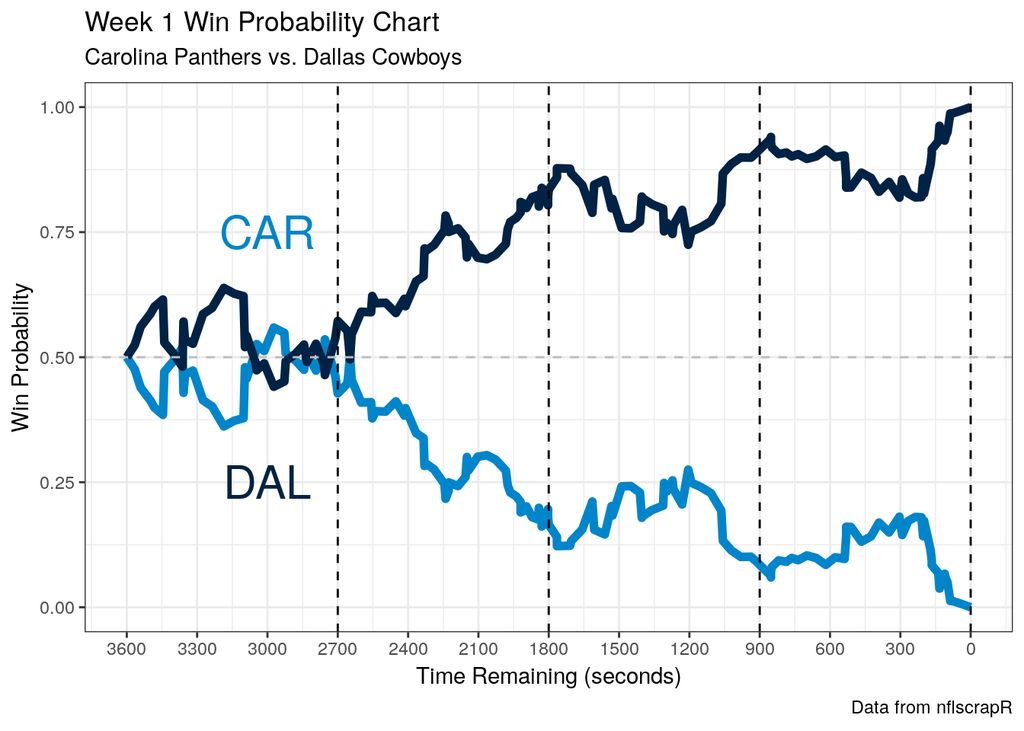

```r
# DFS <- dal_season %>% left_join(all_2018_games)
cardal_wp <- CAR_DAL %>%
  filter(!is.na(home_wp),
         !is.na(away_wp)) %>% unite(GIDGSR, game_seconds_remaining, game_id, sep=":")
cardal_wp <- cardal_wp %>% dplyr::select(GIDGSR,
                home_wp,
                away_wp) %>%
  gather(team, wpa, -GIDGSR) %>% separate(., GIDGSR, c("GSR", "game_id"), sep=":") %>%
  mutate(game_seconds_remaining = as.integer(GSR))
cardal_wp %>%  ggplot(aes(x = game_seconds_remaining, y = wpa, color = team)) +
  geom_line(size = 2) +
  geom_hline(yintercept = 0.5, color = "gray", linetype = "dashed") +
  scale_color_manual(labels = c("CAR", "DAL"),
                     values = c(car_color, dal_color),
                     guide = FALSE) +
  scale_x_reverse(breaks = seq(0, 3600, 300)) +
  annotate("text", x = 3000, y = .75, label = "CAR", color = car_color, size = 8) +
  annotate("text", x = 3000, y = .25, label = "DAL", color = dal_color, size = 8) +
  geom_vline(xintercept = 900, linetype = "dashed", black) +
  geom_vline(xintercept = 1800, linetype = "dashed", black) +
  geom_vline(xintercept = 2700, linetype = "dashed", black) +
  geom_vline(xintercept = 0, linetype = "dashed", black) +
  labs(
    x = "Time Remaining (seconds)",
    y = "Win Probability",
    title = "Week 1 Win Probability Chart",
    subtitle = "Carolina Panthers vs. Dallas Cowboys",
    caption = "Data from nflscrapR"
  ) + theme_bw()
```

Now I want to try and build a plot of all of Dallas Cowboys games for the season. Here are the steps. First, I am going to make a table that contains all of the names and colors for all of the game IDs. Even though I only need those for Dallas, building a shiny app for this would mean that I could select by teams above and make it extensible. At the end, I will only need those for Dallas so I will separate them off.

```r
ntable <- all_2018_games %>% group_by(game_id) %>% summarise(home_team = first(home_team), away_team = first(away_team)) %>% ungroup()
ntableH <- ntable
ntableH <- ntableH %>% left_join(nflteams, by = c("home_team" = "abbr"))
names(ntableH) <- paste0("Home_",names(ntableH), sep="")
ntableH <- ntableH %>% rename(., game_id = Home_game_id, home_team = Home_home_team, away_team = Home_away_team)
ntableA <- ntable
ntableA <- ntableA %>% left_join(nflteams, by = c("away_team" = "abbr"))
names(ntableA) <- paste0("Away_",names(ntableA), sep="")
ntableA <- ntableA %>% rename(., game_id = Away_game_id, home_team = Away_home_team, away_team = Away_away_team)
My.NFL.Table <- ntableH %>% inner_join(ntableA)
Dallas.Table <- My.NFL.Table %>% filter(home_team=="DAL" | away_team=="DAL")
Dallas.Table %>% head()
```

```
## # A tibble: 6 x 15
##   game_id home_team away_team Home_team Home_primary Home_secondary
##   <chr>   <chr>     <chr>     <chr>     <chr>        <chr>
## 1 201809… CAR       DAL       Carolina… #0085ca      #000000
## 2 201809… DAL       NYG       Dallas C… #002244      #b0b7bc
## 3 201809… SEA       DAL       Seattle … #002244      #69be28
## 4 201809… DAL       DET       Dallas C… #002244      #b0b7bc
## 5 201810… HOU       DAL       Houston … #03202f      #a71930
## 6 201810… DAL       JAX       Dallas C… #002244      #b0b7bc
## # … with 9 more variables: Home_tertiary <chr>, Home_quaternary <chr>,
## #   Home_division <chr>, Away_team <chr>, Away_primary <chr>,
## #   Away_secondary <chr>, Away_tertiary <chr>, Away_quaternary <chr>,
## #   Away_division <chr>
```

One nice little bit of data recovery here, the season schedule.

```r
Dallas.Table %>% select(game_id,Home_team,Away_team)
```

```
## # A tibble: 16 x 3
##    game_id    Home_team           Away_team
##    <chr>      <chr>               <chr>
##  1 2018090910 Carolina Panthers   Dallas Cowboys
##  2 2018091613 Dallas Cowboys      New York Giants
##  3 2018092312 Seattle Seahawks    Dallas Cowboys
##  4 2018093002 Dallas Cowboys      Detroit Lions
##  5 2018100712 Houston Texans      Dallas Cowboys
##  6 2018101410 Dallas Cowboys      Jacksonville Jaguars
##  7 2018102110 Washington Redskins Dallas Cowboys
##  8 2018110500 Dallas Cowboys      Tennessee Titans
##  9 2018111111 Philadelphia Eagles Dallas Cowboys
## 10 2018111800 Atlanta Falcons     Dallas Cowboys
## 11 2018112201 Dallas Cowboys      Washington Redskins
## 12 2018112900 Dallas Cowboys      New Orleans Saints
## 13 2018120912 Dallas Cowboys      Philadelphia Eagles
## 14 2018121605 Indianapolis Colts  Dallas Cowboys
## 15 2018122306 Dallas Cowboys      Tampa Bay Buccaneers
## 16 2018123008 New York Giants     Dallas Cowboys
```

The first thing to notice is that this color scheme thing is going to cause trouble when Dallas plays the Seahawks that apparently have the same primary color. For now, I think that I will just make the opponent some constant color.

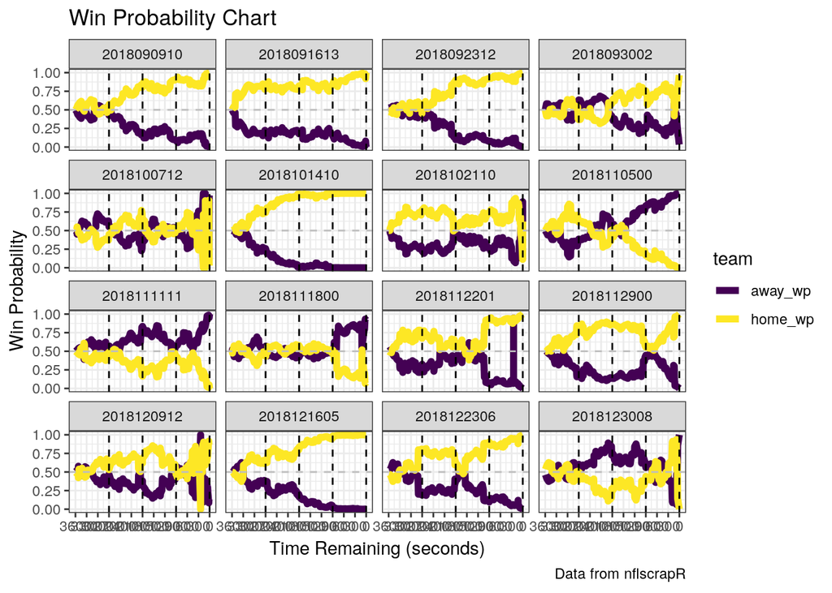

```r
dal_wp <- dal_season %>%
  filter(!is.na(home_wp),
         !is.na(away_wp)) %>% unite(GIDGSR, game_seconds_remaining, game_id, sep=":")
dal_wp <- dal_wp %>% dplyr::select(GIDGSR,
                home_wp,
                away_wp)  %>%
  gather(team, wpa, -GIDGSR) %>% separate(., GIDGSR, c("GSR", "game_id"), sep=":") %>%
  mutate(game_seconds_remaining = as.integer(GSR))
dal_wp %>% ggplot(aes(x = game_seconds_remaining, y = wpa, color = team)) +
  geom_line(size = 2) +
  geom_hline(yintercept = 0.5, color = "gray", linetype = "dashed") +
  scale_color_viridis_d() +
#  scale_color_manual(labels = c("CAR", "DAL"),
#                     values = c("#7FFF00", dal_color),
#                     guide = FALSE) +
  scale_x_reverse(breaks = seq(0, 3600, 300)) +
#  annotate("text", x = 3000, y = .75, label = "CAR", color = "#7FFF00", size = 8) +
#  annotate("text", x = 3000, y = .25, label = "DAL", color = dal_color, size = 8) +
  geom_vline(xintercept = 900, linetype = "dashed", black) +
  geom_vline(xintercept = 1800, linetype = "dashed", black) +
  geom_vline(xintercept = 2700, linetype = "dashed", black) +
  geom_vline(xintercept = 0, linetype = "dashed", black) +
  labs(
    x = "Time Remaining (seconds)",
    y = "Win Probability",
    title = "Win Probability Chart",
#    subtitle = "Carolina Panthers vs. Dallas Cowboys",
    caption = "Data from nflscrapR"
  ) + theme_bw() + facet_wrap(~game_id)
```